# STAT167 Lab #3 - Spring 2021

Deisy Diaz

ddiaz022@ucr.edu

2021/4/16

# **Discussion week 3 instructions**

This week, we will review some `ggplot2` example figures from the lectures.

- First, download the `rmd` file from iLearn.
- Open this `rmd` file in RStudio and click `Knit -> Knit to HTML` to render it to HTML format. (The computer lab computers do not have `LaTex` installed so you can not render it to PDF format).
- Read this `rmd` file and the rendered `html` file side-by-side, to see how this document was generated!
- Be sure to play with this document! Change it. Break it. Fix it. The best way to learn R Markdown (or really almost anything) is to try, fail, then find out what you did wrong.
- Read over the `ggplot2` example code and check the output. If you have any questions about certain functions or parameters, it is the time to ask!
- There are some exercises through out this document. Replace **INSERT_YOUR_ANSWER** with your own answers. Knit the file to HTML, and check your results.

**Please comment your R code thoroughly, and follow the R coding style guideline (https://google.github.io/styleguide/Rguide.xml). Partial credit will be deducted for insufficient commenting or poor coding styles.**

**Lab submission guideline**

- After you completed all exercises, save your file to `FirstnameLastname-SID-lab3.rmd` and save the rendered html/pdf file to `FirstnameLastname-SID-lab3.html` or `FirstnameLastname-SID-lab3.pdf`.
- Submit **BOTH your source `rmd` file and the knitted `html` or `pdf` file** to **GradeScope**. Do NOT create a zip file. You can submit multiple times, you last submission will be graded.

# **Lecture Review - `ggplot2`**

## Install the `tidyverse` package

```r
# install the tidyverse package first if you have not done it  yet.
#install.packages("tidyverse") # you can comment out this line after you have installed `tidyverse`
library(tidyverse)
```

## The `mpg` data set

This data set contains fuel economy data 1999 - 2008 for 38 popular car models (source: EPA. [fueleconomy.com/](http://fueleconomy.gov)).

```r
?mpg
## starting httpd help server ... done
dim(mpg)  # dimension of the table
```

```
## [1] 234  11
```

```r
mpg  # print/view mpg (we will introduce tibble later in this class)
```

```
## # A tibble: 234 x 11
##    manufacturer model    displ  year   cyl trans   drv     cty   hwy fl    class
##    <chr>        <chr>    <dbl> <int> <int> <chr>   <chr> <int> <int> <chr> <chr>
##  1 audi         a4         1.8  1999     4 auto(l~ f        18    29 p     comp~
##  2 audi         a4         1.8  1999     4 manual~ f        21    29 p     comp~
##  3 audi         a4         2    2008     4 manual~ f        20    31 p     comp~
##  4 audi         a4         2    2008     4 auto(a~ f        21    30 p     comp~
##  5 audi         a4         2.8  1999     6 auto(l~ f        16    26 p     comp~
##  6 audi         a4         2.8  1999     6 manual~ f        18    26 p     comp~
##  7 audi         a4         3.1  2008     6 auto(a~ f        18    27 p     comp~
##  8 audi         a4 quat~   1.8  1999     4 manual~ 4        18    26 p     comp~
##  9 audi         a4 quat~   1.8  1999     4 auto(l~ 4        16    25 p     comp~
## 10 audi         a4 quat~   2    2008     4 manual~ 4        20    28 p     comp~
## # ... with 224 more rows
```

```r
str(mpg)  # list the structures in mpg
## tibble [234 x 11] (S3: tbl_df/tbl/data.frame)
##  $ manufacturer: chr [1:234] "audi" "audi" "audi" "audi" ...
##  $ model       : chr [1:234] "a4" "a4" "a4" "a4" ...
##  $ displ       : num [1:234] 1.8 1.8 2 2 2.8 2.8 3.1 1.8 1.8 2 ...
##  $ year        : int [1:234] 1999 1999 2008 2008 1999 1999 2008 1999 1999 2008 ...
##  $ cyl         : int [1:234] 4 4 4 4 6 6 6 4 4 4 ...
##  $ trans       : chr [1:234] "auto(l5)" "manual(m5)" "manual(m6)" "auto(av)" ...
##  $ drv         : chr [1:234] "f" "f" "f" "f" ...
##  $ cty         : int [1:234] 18 21 20 21 16 18 18 18 16 20 ...
##  $ hwy         : int [1:234] 29 29 31 30 26 26 27 26 25 28 ...
##  $ fl          : chr [1:234] "p" "p" "p" "p" ...
##  $ class       : chr [1:234] "compact" "compact" "compact" "compact" ...
glimpse(mpg) # get a glimpse of the mpg data
```

```
## Rows: 234
## Columns: 11
## $ manufacturer <chr> "audi", "audi", "audi", "audi", "audi", "audi", "audi"...
## $ model        <chr> "a4", "a4", "a4", "a4", "a4", "a4", "a4", "a4 quattro"...
## $ displ        <dbl> 1.8, 1.8, 2.0, 2.0, 2.8, 2.8, 3.1, 1.8, 1.8, 2.0, 2.0,...
## $ year         <int> 1999, 1999, 2008, 2008, 1999, 1999, 2008, 1999, 1999, ...
## $ cyl          <int> 4, 4, 4, 4, 6, 6, 6, 4, 4, 4, 4, 6, 6, 6, 6, 6, 6, 8, ...
## $ trans        <chr> "auto(l5)", "manual(m5)", "manual(m6)", "auto(av)", "a...
## $ drv          <chr> "f", "f", "f", "f", "f", "f", "f", "4", "4", "4", "4",...
## $ cty          <int> 18, 21, 20, 21, 16, 18, 18, 18, 16, 20, 19, 15, 17, 17...
## $ hwy          <int> 29, 29, 31, 30, 26, 26, 27, 26, 25, 28, 27, 25, 25, 25...
## $ fl           <chr> "p", "p", "p", "p", "p", "p", "p", "p", "p", "p", "p",...
## $ class        <chr> "compact", "compact", "compact", "compact", "compact",...
```

## The complete graphing template in `ggplot2`

```r
ggplot(data = <DATA>) +
  <GEOM_FUNCTION>(
     mapping = aes(<MAPPINGS>),
     stat = <STAT>,        # optional
     position = <POSITION> # optional
  ) +
  <COORDINATE_FUNCTION> +  # optional
  <FACET_FUNCTION> +       # optional
  <SCALE_FUNCTION> +       # optional
  <THEME_FUNCTION>         # optional
```

## Example: aesthetic mappings for both `geom_point()` and `geom_smooth()`

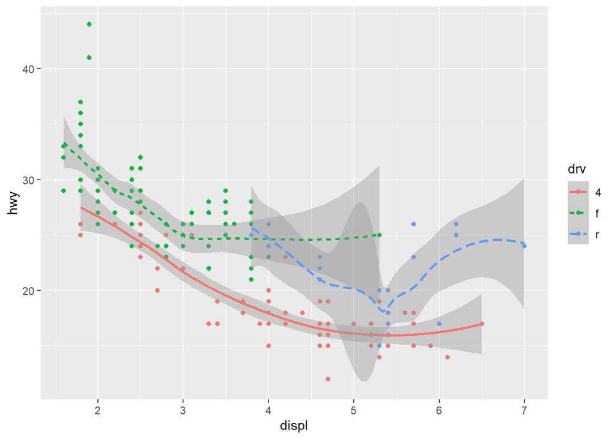

```r
ggplot(data = mpg,
       mapping = aes(x = displ, y = hwy, col = drv) # global mapping
       ) +
  geom_point() +
  geom_smooth(mapping = aes(linetype = drv)) # local mapping for the layer
## `geom_smooth()` using method = 'loess' and formula 'y ~ x'
```

### **Exercise #1**

Write your own `ggplot2` code to make a scatterplot of `cty` against `displ`; add a regression line to your plot; map `drv` to the color aesthetic for both points and lines; map `cyl` to the `size` aesthetic for points.

**ANSWER:**

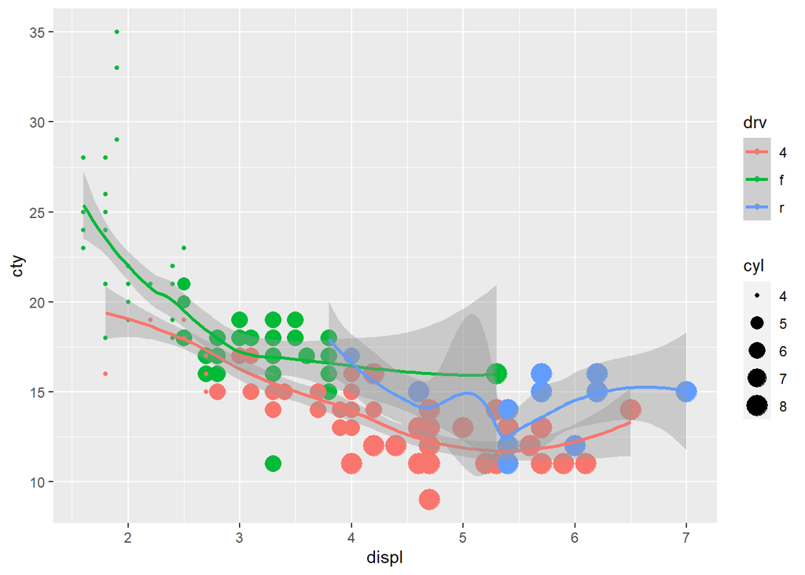

```r
ggplot(data = mpg,
       mapping = aes(x = displ, y = cty, col = drv) # global mapping
       ) +
  geom_point(mapping = aes(size = cyl)) +
  geom_smooth(mapping = aes(color = drv)) # local mapping for the layer
## `geom_smooth()` using method = 'loess' and formula 'y ~ x'
```

What you can conclude from your figure?

**ANSWER:** As the cylinder size grows so does displacement but city mileage decreases.